# Data Analysis at Exploristics

This document is a starter report that fits the branding of the [Exploristics](https://exploristics.com) company.  
Exploristics is a biostatistics company providing advanced **data analytics solutions** to the pharmaceutical, healthcare, and life sciences industries.

Author: Holtz Yan

Date: September 27, 2024

## Introduction

`Lumo` is a Quarto [custom format](https://github.com/holtzy/lumo). Basically a few tweaks around the default appearance of a Quarto document, ready to be used for your own project.

This document shows how Lumo can be adapted to fit the branding of [Exploritics](https://exploristics.com)

Btw, you can learn how to master Quarto with my [Productive R Workflow](https://www.productive-r-workflow.com) project!

## Load Packages

Make sure to load **all your packages** at the start of your document for clarity and consistency.

Notice that the code chunks are folded by default. You can adjust this behavior with the `code-fold` option in the document’s YAML header.

```r
library(tidyverse)
library(hrbrthemes)
library(sf)
library(leaflet)
```

**1**

this package provides my favorite `ggplot2` theme: `theme_ipsum()`

By the way, you should open the code chunk that is folded above. ⬆️ There is a little stunning surprise on its right hand side.

## Dataviz theme

```r
library(ggplot2)
library(hrbrthemes)

dataviz_theme <- function() {
  theme_ipsum() +
    theme(
      plot.title = element_text(color = params$primaryColor, size = 18, face = "bold"),
      axis.text.x = element_text(size = 7),
      axis.text.y = element_text(size = 7),
      panel.background = element_rect(fill = scales::alpha(params$primaryColor, 0.1), color = NA),  # 50% opacity
      plot.background = element_rect(fill = scales::alpha(params$primaryColor, 0.1)),  # Set plot background color
      panel.grid = element_line(color = "transparent")                   # Optional: make grid lines transparent
    )
}

theme_set(dataviz_theme())
```

## Where is Exploristics?

Let’s find out thanks to `leafet`

```r
# Load the library.
library(leaflet)

# Make a map
leaflet() %>%
  addTiles() %>% # Add default OpenStreetMap map tiles
  addMarkers(lng = -5.9302, lat = 54.5968, popup = "Exploristics Headquarters") %>%
  setView(lng = -5.9302, lat = 54.5968, zoom = 10)  # Change zoom level here
```

[interactive chart not shown]

## Interactive table

It is very easy to insert an interactive table in your document thanks to the `DT` package. The output allows to filter rows, search for something and sort using a specific columns!

Install the library with `install.packages("DT")`. Then, just pass a dataframe to the `datatable()` function to get a stunning interactive output!

```r
library(DT)
data(iris)

# Make a table
datatable(iris, filter = "top")
```

|  | Sepal.Length | Sepal.Width | Petal.Length | Petal.Width | Species |
| --- | --- | --- | --- | --- | --- |
| 1 | 5.1 | 3.5 | 1.4 | 0.2 | setosa |
| 2 | 4.9 | 3 | 1.4 | 0.2 | setosa |
| 3 | 4.7 | 3.2 | 1.3 | 0.2 | setosa |
| 4 | 4.6 | 3.1 | 1.5 | 0.2 | setosa |
| 5 | 5 | 3.6 | 1.4 | 0.2 | setosa |
| 6 | 5.4 | 3.9 | 1.7 | 0.4 | setosa |
| 7 | 4.6 | 3.4 | 1.4 | 0.3 | setosa |
| 8 | 5 | 3.4 | 1.5 | 0.2 | setosa |
| 9 | 4.4 | 2.9 | 1.4 | 0.2 | setosa |
| 10 | 4.9 | 3.1 | 1.5 | 0.1 | setosa |

[output cut: 140 more lines]

I’ve added a bit of CSS to make the font smaller on DT tables by the way 🙂

## A grey section

It’s always good to have a grey section. Makes the document breath a bit. I’ve added a little utility class in `Lumo` to make sure you can make sections like this very easily. Check the [documentation](https://www.productive-r-workflow.com/r/bonus/lumo-quarto-template)!

Let’s use this space to render a little equation:

$$x = \frac{-b \pm \sqrt{b^2 - 4ac}}{2a}$$

## Quarto Tricks

`Lumo` is a great format, but to get the most out of it, you’ll need to master a few Quarto tricks!

The good news? I’ve compiled my 30+ favorite tips [in one place](https://www.productive-r-workflow.com/quarto-tricks). Just spend 30 minutes, and you’ll be up to speed with all of them!

For example, if you’re creating multiple plots, each highlighting different aspects of your dataset, consider using *pills* to organize them!

**Scatterplot**

This is a good old scatterplot of the iris dataset. If you want to learn more about how to make graphs in R, visit my [R graph gallery](https://www.r-graph-gallery.com)!

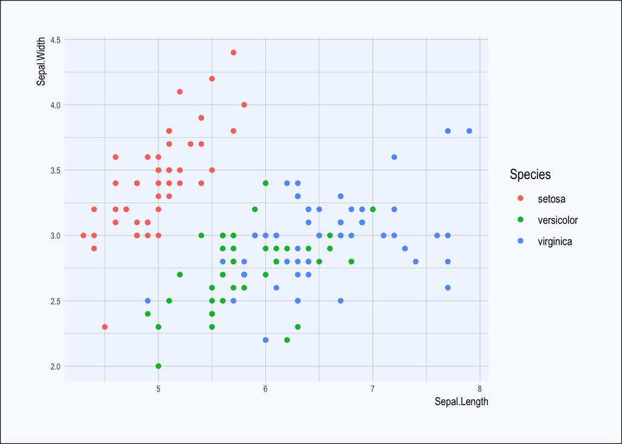

```r
ggplot(iris, aes(x=Sepal.Length, y=Sepal.Width, color=Species)) +
    geom_point()
```

**Boxplot**

You can also make a [boxplot](https://r-graph-gallery.com/89-box-and-scatter-plot-with-ggplot2.html), but please do not hide the underlying distribution! This is widely explain in my data-to-viz.com project in case you’re not convinced 😋. Check the next tab to get convinced!

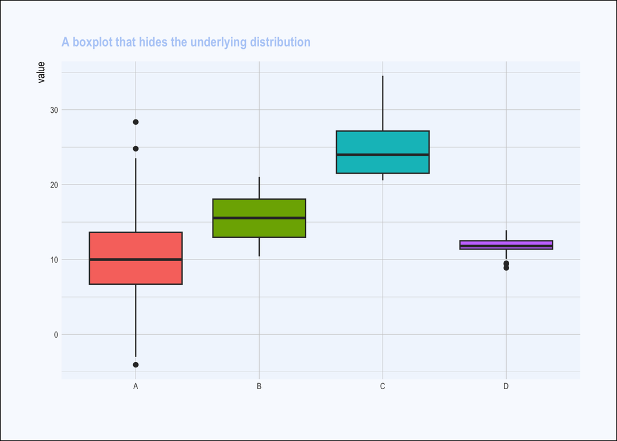

```r
# create a dataset
data <- data.frame(
  name=c( rep("A",500), rep("B",500), rep("B",500), rep("C",20), rep('D', 100)  ),
  value=c( rnorm(500, 10, 5), rnorm(500, 13, 1), rnorm(500, 18, 1), rnorm(20, 25, 4), rnorm(100, 12, 1) )
)

# Plot
data %>%
  ggplot( aes(x=name, y=value, fill=name)) +
    geom_boxplot() +
    theme(
      legend.position="none",
      plot.title = element_text(size=11)
    ) +
    ggtitle("A boxplot that hides the underlying distribution") +
    xlab("")
```

**Jittering**

See what’s happening now that the individual data points are visible! Would be a shame to miss this.

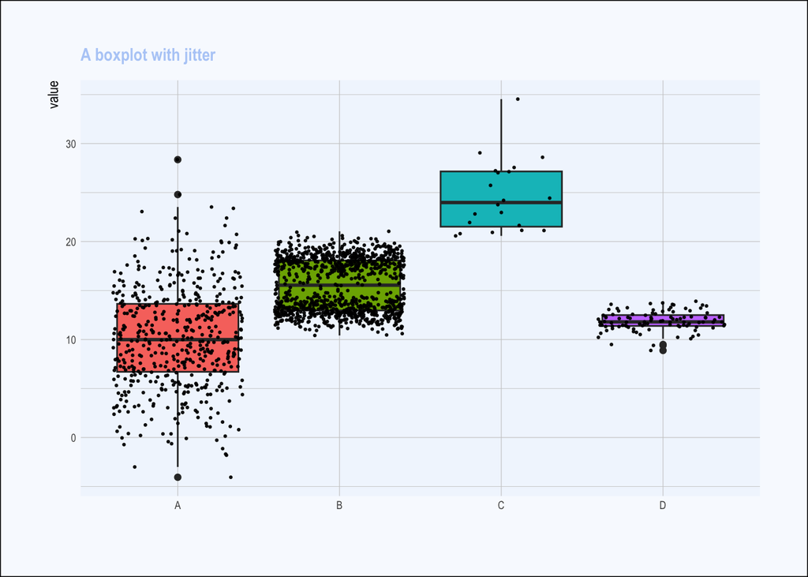

```r
data %>%
  ggplot( aes(x=name, y=value, fill=name)) +
    geom_boxplot() +
    geom_jitter(color="black", size=0.4, alpha=0.9) +
    theme(
      legend.position="none",
      plot.title = element_text(size=11)
    ) +
    ggtitle("A boxplot with jitter") +
    xlab("")
```

## More Information

Learn how to use and how to customize `Lumo` [here](https://www.productive-r-workflow.com/r/bonus/lumo-quarto-template).

## Session Info

When creating a Quarto document, it’s a good practice to include details about your **working environment**.

This is easy to do—just call `sessionInfo()`, and it will print out all your R and package versions. This simple step greatly enhances **reproducibility**.

[session information not shown]